# Predicting Excessive Enforcement Patterns in Police Behavior After Vehicles Stops in New York

Gianmaria Pizzo

These `.Rmd` files represent the project submission for the course [Statistical Inference and Learning](https://www.unive.it/data/course/451271) by Professor [Cristiano Varin](https://www.unive.it/data/people/5592728) at [Ca’ Foscari University of Venice](https://www.unive.it/) for the year 2024/2025.

# Problem Statement

## Goal of the Project

As the title of the project suggests, the goal of the project is to assess **whether** we can say (with enough confidence) that the **police behavior shows excessive enforcement patterns**, after a vehicle stop has been conducted.

In particular, we focus on studying if there exist relationships between violent outcomes and specific groups of people, or areas. This should help to shed some light on the alleged “systemic nature” of the stops.

However, some of the limiting factors for our study, include the small time frame of the data, the absence of information about the reason behind the halt, the self-report nature of some variables and the partial anonymization of the values.

Thus, this analysis will not be limited to performing basic univariate, bivariate or multivariate exploratory analysis. Instead, we first start from formatting the data in a way we can understand the meaning of each variable, and the issues that come with it.

Furthermore, we may also introduce transformations or other means of engineering, until we feel satisfied with the final data. We might add new insights about the effects of time-of-day, day-of-week, precinct to reveal new observations, such as whether racial disparities peak during specific hours or hot-spots.

All of the manipulations, are to be carefully tested for. In fact, we might end up using some automatic variable selection approach to and other means of model selection.

Only then, we can proceed to design the final plot, check for outliers and collinearity, and formulate our main assumptions. We want to prevent complex interactions between terms that might limit the interpretability. This does not mean we are not going to try and evaluate combinations of features (that may also substitute the initial ones) nonetheless. The result of this initial part, aims to increase the reliability of the information, crucial to the next step.

The core of this project is to pragmatically build, analyze and interpret (multiple) predictive models capable of estimating whether a stop escalates into a search, seizure, arrest, or use-of-force based (forecasting outcome) and the significance of the factors used to build such models. This means, we want to differentiate between different target features by context.

Therefore, this requires an extensive training process, including the use of k-fold-cross validation, subset selection and other techniques to promote theoretical and empirical validity.

Finally, as this is mainly a classification problem, we will include all possible classification metrics and perform extensive tests. We hope to quantify both the accuracy and the confidence of our inferences to determine what this data is telling us.

## Previous Research and Novel Approach

Even though there exist some public reports (e.g., [NYCLU - NYPD Vehicle Stops Data](https://www.nyclu.org/data/nypd-vehicle-stops-data)), they only cover descriptive statistics.

As already stated above, our analysis will provide a better insight, through predictive modeling, model comparison (via AIC and cross-validation), and inference on interactions (e.g., race × time or precinct).

We hope this analysis dissipates or pinpoints the police bias clearly, even with limited data, as it might lead to either confirming that some areas and races are more subject to police enforcement than others, or that this has been a product of the prominent propaganda, and the police is “just doing its job”.

Last but not least, we do not approach the data with any prior research bias, unlike many journalists.

## Questions we want to ask

Obviously, we could not proceed forward if we did not have some designated questions for our data.

Is it more likely to be the subject of an episode of excessive enforcement behavior…

- When stopped in a specific area (or borough)?
- When stopped by a specific command unit?
- When stopped outside of the 9am-5pm “window”?
- When stopped during the weekend?
- If the driver is under 35 years old?
- If the driver belongs to a specific ethnicity?
- If the driver identifies with a specific gender?
- If the vehicles used belongs to a specific category?

Furthermore, we may also formulate questions of the kind

- Is there a specific sub-category of drivers that is subject of most of these episodes?
- Is there a specific ethnicity targeted by excessive enforcement behavior in a particular area?
- Proportionally speaking, since Donald Trump became president (January 20, 2025), has any of the previous aspect changed?

## Goal of this rmarkdown file - TODO

The EDA is the first step to understanding the data and its nature.

This includes analyzing the single features (Univariate Analysis), their interactions with the target (Bivariate Analysis) and their interactions with other features (Multivariate Analysis and Collinearity Check). However, the latter might be hard to compute as it requires the estimation of a regression model that follows certain assumptions and it is usually easier to check this when using linear models.

During my exploration I will look out for possible outliers, correlation and any other statistically relevant problem that might affect my final prediction.

We will start with the environment.

Note that, from now on, I will shift adopt a more **formal or inclusive tone** (e.g., the “editorial we”).

# Environment

The first to do, is to build a reproducible environment for our project.

```r
requirements=c(
  "remotes", "summarytools", "forcats", "scales", "purrr",
  "stringr", "plyr", "dbplyr", "dplyr", "dtplyr", "tidyr", "tidyselect",
  "timeDate", "timechange", "tzdb", "hms", "readr",
  "lubridate", "prettyunits", "RColorBrewer", "viridis", "rcartocolor", "ggbeeswarm", "emmeans",
  "sf", "plotly", "ggplot2", "ggmap", "ggdensity", "UpSetR", "patchwork"
)
```

Note that some of the packages may not be used, but to avoid any error related to dependencies, we are going to keep all of these libraries. Now, the loading of all packages should be immediate.

Let us load the data now.

```r
vehstops = read.csv("data/vehiclestops.csv")
vehstops2 = read.csv("data/vehiclestops_clean.csv")
```

```r
summary(vehstops)
```

```
##       year          month             day             doy           dow
##  Min.   :2023   Min.   : 1.000   Min.   : 1.00   Min.   :  1   Min.   :1.00
##  1st Qu.:2023   1st Qu.: 3.000   1st Qu.: 8.00   1st Qu.: 67   1st Qu.:2.00
##  Median :2024   Median : 5.000   Median :15.00   Median :138   Median :4.00
##  Mean   :2024   Mean   : 5.604   Mean   :15.41   Mean   :155   Mean   :3.89
##  3rd Qu.:2024   3rd Qu.: 8.000   3rd Qu.:23.00   3rd Qu.:239   3rd Qu.:5.00
##  Max.   :2025   Max.   :12.000   Max.   :31.00   Max.   :366   Max.   :7.00
##
##    weekday             weekend          holiday          event_day
##  Length:2039861     Min.   :0.0000   Min.   :0.00000   Min.   :0.00000
##  Class :character   1st Qu.:0.0000   1st Qu.:0.00000   1st Qu.:0.00000
##  Mode  :character   Median :0.0000   Median :0.00000   Median :0.00000
##                     Mean   :0.2288   Mean   :0.03233   Mean   :0.04289
##                     3rd Qu.:0.0000   3rd Qu.:0.00000   3rd Qu.:0.00000
##                     Max.   :1.0000   Max.   :1.00000   Max.   :1.00000
##
##       hour           minute       working_hour    time_bracket
##  Min.   : 0.00   Min.   : 0.00   Min.   :0.0000   Length:2039861
##  1st Qu.: 9.00   1st Qu.:14.00   1st Qu.:0.0000   Class :character
##  Median :15.00   Median :29.00   Median :0.0000   Mode  :character
##  Mean   :13.28   Mean   :28.68   Mean   :0.3656
##  3rd Qu.:19.00   3rd Qu.:44.00   3rd Qu.:1.0000
##  Max.   :23.00   Max.   :59.00   Max.   :1.0000
##
##     latitude        longitude          area               boro
##  Min.   : 0.00    Min.   :-74.25   Length:2039861     Length:2039861
##  1st Qu.:40.52    1st Qu.:-73.96   Class :character   Class :character
##  Median :40.68    Median :-73.90   Mode  :character   Mode  :character
##  Mean   :30.87    Mean   :-56.23
##  3rd Qu.:40.76    3rd Qu.:-73.74
##  Max.   :40.91    Max.   :  0.00
##  NA's   :123475   NA's   :102486
##     command           sex                race                age
##  Min.   :  1.00   Length:2039861     Length:2039861     Min.   : 16.00
##  1st Qu.: 43.00   Class :character   Class :character   1st Qu.: 27.00
##  Median : 69.00   Mode  :character   Mode  :character   Median : 35.00
##  Mean   : 69.18                                         Mean   : 37.71
##  3rd Qu.:105.00                                         3rd Qu.: 46.00
##  Max.   :123.00                                         Max.   :120.00
##                                                         NA's   :108367
```

[output cut: 25 more lines]

```
##  Min.   :0.0000000   Min.   :0.00000   Min.   :0.00000       Min.   :0.000000
##  1st Qu.:0.0000000   1st Qu.:0.00000   1st Qu.:0.00000       1st Qu.:0.000000
##  Median :0.0000000   Median :0.00000   Median :0.00000       Median :0.000000
##  Mean   :0.0007089   Mean   :0.03381   Mean   :0.00698       Mean   :0.006375
##  3rd Qu.:0.0000000   3rd Qu.:0.00000   3rd Qu.:0.00000       3rd Qu.:0.000000
##  Max.   :1.0000000   Max.   :1.00000   Max.   :1.00000       Max.   :1.000000
##
##  force_and_arrest    any_escalation
##  Min.   :0.0000000   Min.   :0.00000
##  1st Qu.:0.0000000   1st Qu.:0.00000
##  Median :0.0000000   Median :0.00000
##  Mean   :0.0006584   Mean   :0.06101
##  3rd Qu.:0.0000000   3rd Qu.:0.00000
##  Max.   :1.0000000   Max.   :1.00000
##
```

# Univariate EDA

In this part we perform a deeper analysis of the target feature, and some of the most important features (according to the domain knowledge in notebook 0) against their distribution in the dataset.

Our goal here is to polish the data, by removing outliers and possible confounders that may introduce bias. Furthermore, we need to understand its distribution and normalizing it if necessary.

Possibly, we can introduce new variables that are transformations or combinations of other ones, and evaluate their contributions later with a bivariate analysis and/or model testing.

Hopefully, this process will reduce the variance.

## Target feature distribution

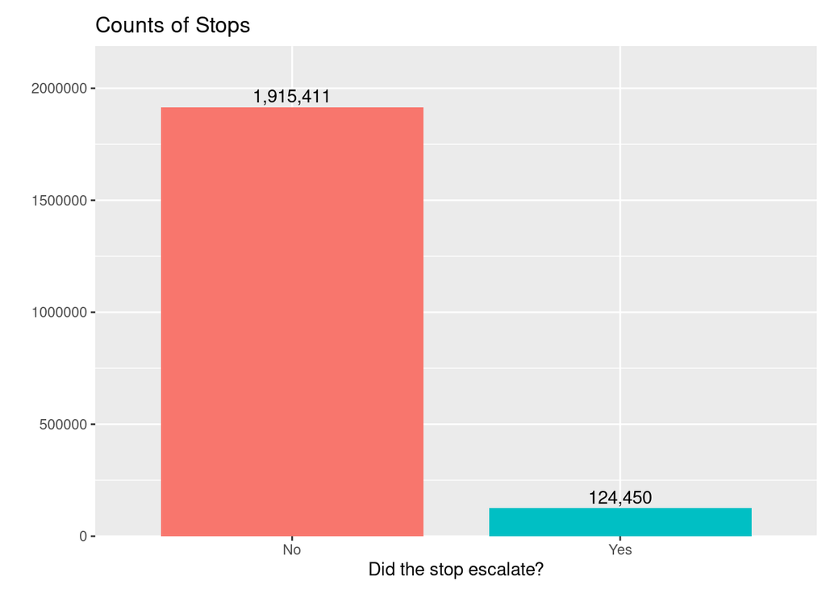

```r
plot_binary_bar(
  vehstops, any_escalation,
  "No", "Yes",
  "Did the stop escalate?", "", "Counts of Stops"
)
```

## Enforcement and Escalation features Distribution

### Core Outcomes

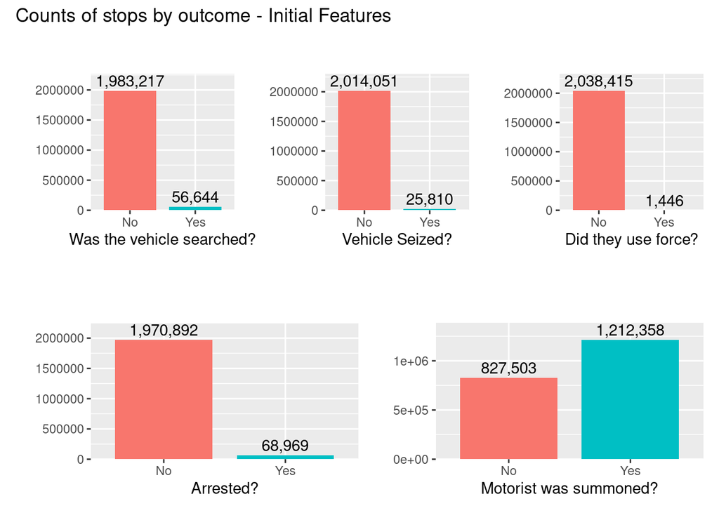

```r
p1 <- plot_binary_bar(
  vehstops, veh_searched,
  "No", "Yes",
  "Was the vehicle searched?", "", ""
)

p2 <- plot_binary_bar(
  vehstops, veh_seized,
  "No", "Yes",
  "Vehicle Seized?", "", ""
)

p3 <- plot_binary_bar(
  vehstops, force_used,
  "No", "Yes",
  "Did they use force?", "", ""
)

p4 <- plot_binary_bar(
  vehstops, arrested,
  "No", "Yes",
  "Arrested?", "", ""
)

p5 <- plot_binary_bar(
  vehstops, summoned,
  "No", "Yes",
  "Motorist was summoned?", "", ""
)


row1 <- p1 | p2 | p3
row2 <- p4 | p5

row1 / plot_spacer() / row2 +
  plot_layout(heights = c(1, 0.08, 1), guides = "collect") +
  plot_annotation(title = "Counts of stops by outcome - Initial Features") &
  theme(legend.position = "bottom")
```

### Extra Outcomes

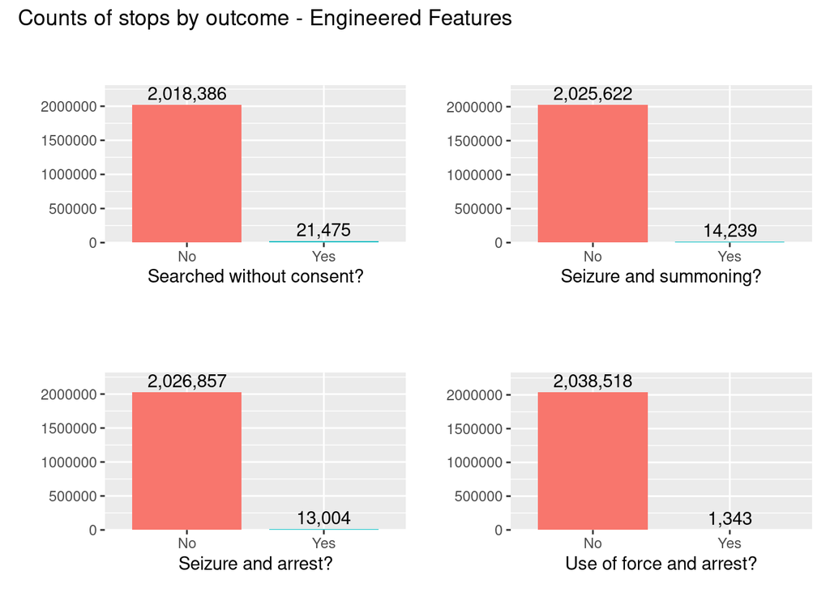

```r
p1 <- plot_binary_bar(
  vehstops, search_without_consent,
  "No", "Yes",
  "Searched without consent?", "", ""
)

p2 <- plot_binary_bar(
  vehstops, seizure_and_summoning,
  "No", "Yes",
  "Seizure and summoning?", "", ""
)

p3 <- plot_binary_bar(
  vehstops, seizure_and_arrest,
  "No", "Yes",
  "Seizure and arrest?", "", ""
)

p4 <- plot_binary_bar(
  vehstops, force_and_arrest,
  "No", "Yes",
  "Use of force and arrest?", "", ""
)

row1 <- p1 | p2
row2 <- p3 | p4

row1 / plot_spacer() / row2 +
  plot_layout(heights = c(1, 0.08, 1), guides = "collect") +
  plot_annotation(title = "Counts of stops by outcome - Engineered Features") &
  theme(legend.position = "bottom")
```

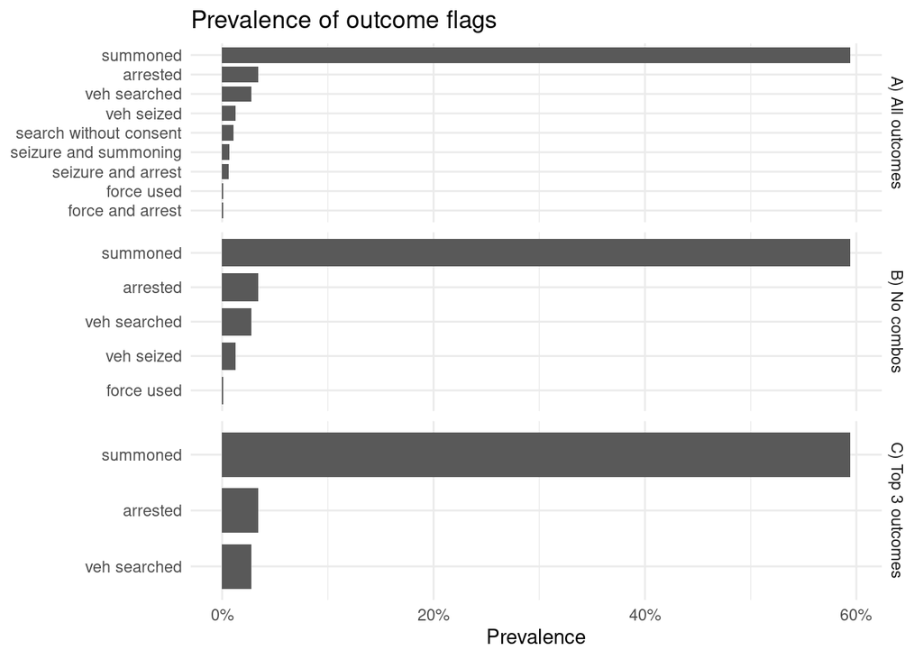

```r
setA_cols <- intersect(
  c("veh_searched","search_without_consent","veh_seized",
    "summoned","force_used","arrested", "seizure_and_summoning","seizure_and_arrest","force_and_arrest"),
  names(vehstops)
)

setB_cols <- intersect(
  c("veh_searched", "veh_seized", "summoned", "arrested", "force_used"),
  names(vehstops)
)

setC_cols <- intersect(
  c("summoned", "veh_searched", "arrested"),
  names(vehstops)
)

A <- vehstops %>%
  select(all_of(setA_cols)) %>%
  pivot_longer(everything(), names_to = "feature", values_to = "val") %>%
  group_by(feature) %>%
  summarise(prevalence = mean(val == 1, na.rm = TRUE), .groups = "drop") %>%
  mutate(set = "A) All outcomes")

B <- vehstops %>%
  select(all_of(setB_cols)) %>%
  pivot_longer(everything(), names_to = "feature", values_to = "val") %>%
  group_by(feature) %>%
  summarise(prevalence = mean(val == 1, na.rm = TRUE), .groups = "drop") %>%
  mutate(set = "B) No combos")

C <- vehstops %>%
  select(all_of(setC_cols)) %>%
  pivot_longer(everything(), names_to = "feature", values_to = "val") %>%
  group_by(feature) %>%
  summarise(prevalence = mean(val == 1, na.rm = TRUE), .groups = "drop") %>%
  mutate(set = "C) Top 3 outcomes")

all_prev <- bind_rows(A, B, C) %>%
  mutate(
    feature = str_replace_all(feature, "_", " "),
    set = factor(set, levels = c("A) All outcomes",
                                 "B) No combos",
                                 "C) Top 3 outcomes"))
  )

all_prev <- all_prev %>%
  mutate(
    feature_set = paste(feature, set, sep = "‖")
  ) %>%
  group_by(set) %>%
  mutate(feature_set = fct_reorder(feature_set, prevalence)) %>%
  ungroup()

ggplot(all_prev, aes(prevalence, feature_set)) +
  geom_col(width = 0.8) +
  scale_x_continuous(labels = percent) +
  scale_y_discrete(labels = function(x) sub("‖.*$", "", x)) +
  labs(x = "Prevalence", y = NULL, title = "Prevalence of outcome flags") +
  facet_grid(rows = vars(set), scales = "free_y") +
  theme_minimal()
```

## Command Unit, Geospatial and Area related Features Distribution

### Area

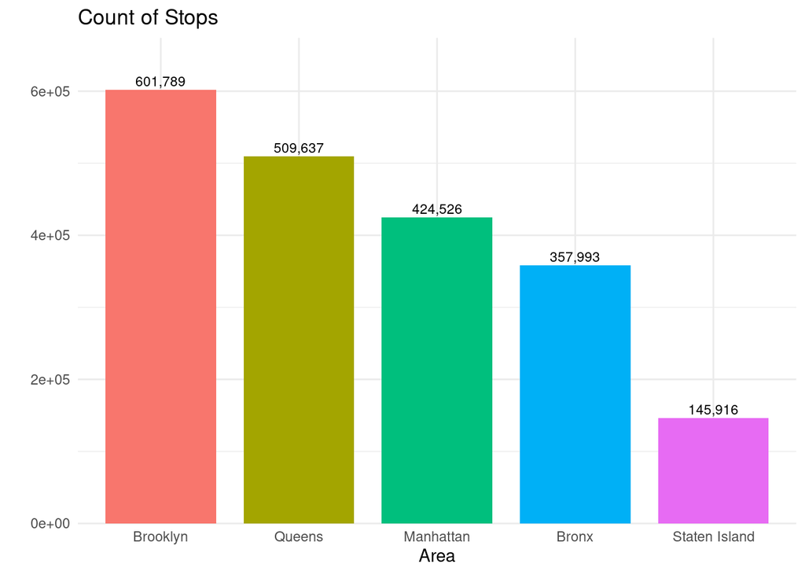

```r
vehstops %>%
  filter(!is.na(area)) %>%
  count(area, name = "n") %>%
  mutate(area = fct_reorder(area, n, .desc = TRUE)) %>%
  ggplot(aes(x = factor(area), y = n, fill = factor(area))) +
  geom_col(width = 0.8, show.legend = FALSE) +
  geom_text(aes(label = scales::comma(n)), vjust = -0.35, size = 3) +
  scale_y_continuous(expand = expansion(mult = c(0, 0.12))) +
  coord_cartesian(clip = "off") +
  labs(x = "Area", y = "", title = "Count of Stops") +
  theme_minimal()
```

### Borough

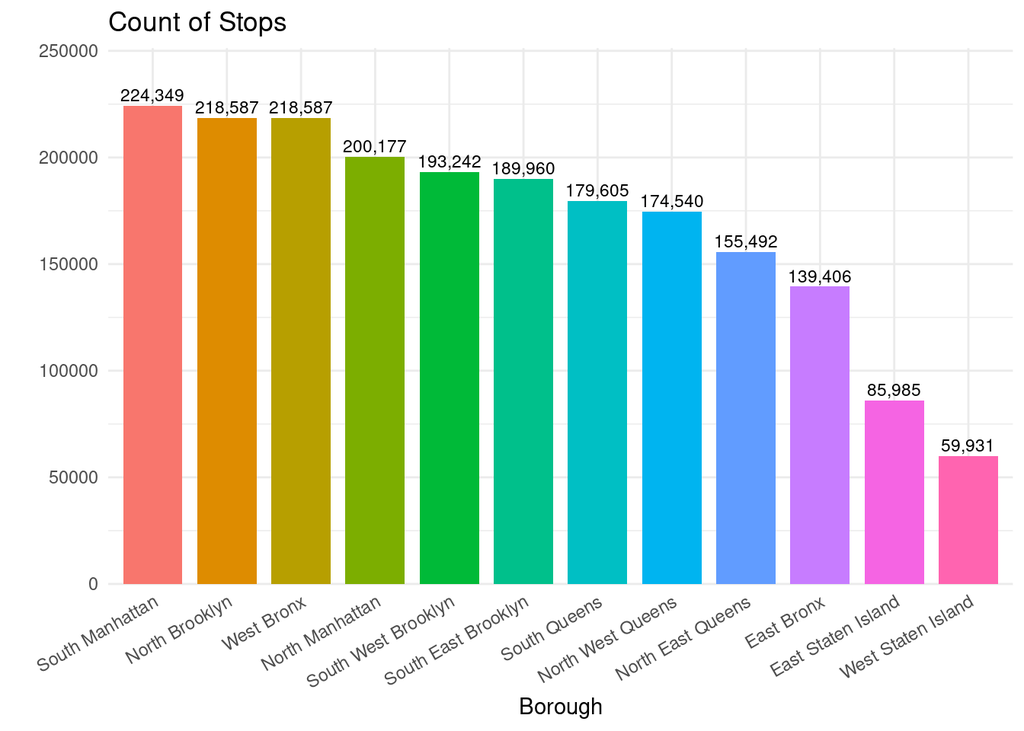

```r
vehstops %>%
  filter(!is.na(boro)) %>%
  count(boro, name = "n") %>%
  mutate(boro = fct_reorder(boro, n, .desc = TRUE)) %>%
  ggplot(aes(x = factor(boro), y = n, fill = factor(boro))) +
  geom_col(width = 0.8, show.legend = FALSE) +
  geom_text(aes(label = scales::comma(n)), vjust = -0.35, size = 3) +
  scale_y_continuous(expand = expansion(mult = c(0, 0.12))) +
  coord_cartesian(clip = "off") +
  labs(x = "Borough", y = "", title = "Count of Stops") +
  theme_minimal() +
  scale_x_discrete(guide = guide_axis(angle = 30, n.dodge = 1))
```

### Command

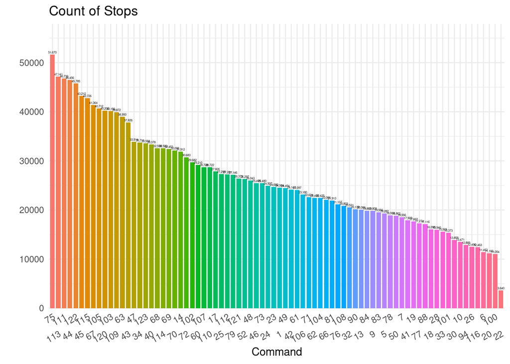

```r
vehstops %>%
  filter(!is.na(command)) %>%
  count(command, name = "n") %>%
  mutate(command = fct_reorder(as.factor(command), n, .desc = TRUE)) %>%
  ggplot(aes(x = factor(command), y = n, fill = factor(command))) +
  geom_col(width = 0.8, show.legend = FALSE) +
  geom_text(aes(label = scales::comma(n)), vjust = -0.5, size = 1) +
  scale_y_continuous(expand = expansion(mult = c(0, 0.12))) +
  coord_cartesian(clip = "off") +
  labs(x = "Command", y = "", title = "Count of Stops") +
  theme_minimal() +
  scale_x_discrete(guide = guide_axis(angle = 30, n.dodge = 2))
```

### Latitude and Longitude

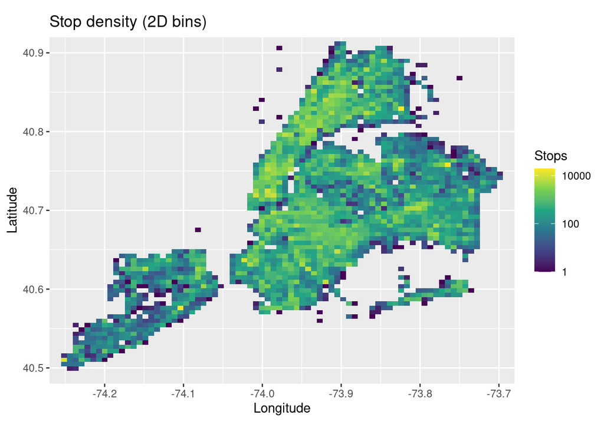

```r
nyc_bbox <- list(lat_min = 40.48, lat_max = 40.92, lon_min = -74.27, lon_max = -73.68)
veh_geo_nyc <- vehstops %>%
  filter(!is.na(latitude), !is.na(longitude)) %>%
  filter(
    between(latitude,  nyc_bbox$lat_min, nyc_bbox$lat_max),
    between(longitude, nyc_bbox$lon_min, nyc_bbox$lon_max)
  )

bins <- 80
min_n <- 25

lon_breaks <- seq(nyc_bbox$lon_min, nyc_bbox$lon_max, length.out = bins + 1)
lat_breaks <- seq(nyc_bbox$lat_min, nyc_bbox$lat_max, length.out = bins + 1)

grid_sum <- veh_geo_nyc %>%
  mutate(
    xbin = cut(longitude, lon_breaks, include.lowest = TRUE, right = FALSE),
    ybin = cut(latitude,  lat_breaks, include.lowest = TRUE, right = FALSE)
  ) %>%
  group_by(xbin, ybin) %>%
  summarise(
    n    = n(),
    rate = mean(any_escalation == 1, na.rm = TRUE),
    .groups = "drop"
  ) %>%
  mutate(
    xi = as.integer(xbin),
    yi = as.integer(ybin),
    # bin centers (for geom_tile positioning)
    x = (lon_breaks[xi] + lon_breaks[xi + 1]) / 2,
    y = (lat_breaks[yi] + lat_breaks[yi + 1]) / 2,
    # optionally suppress super-sparse bins in the rate coloring
    rate_plot = ifelse(n >= min_n, rate, NA_real_)
  )

p1 <- ggplot(grid_sum, aes(x, y, fill = n)) +
  geom_tile() +
  coord_equal(xlim = c(nyc_bbox$lon_min, nyc_bbox$lon_max),
              ylim = c(nyc_bbox$lat_min, nyc_bbox$lat_max), expand = FALSE) +
  scale_fill_viridis_c(trans = "log10", name = "Stops") +
  labs(title = "Stop density (2D bins)", x = "Longitude", y = "Latitude")

p1
```

## Time related features Distribution

### Year

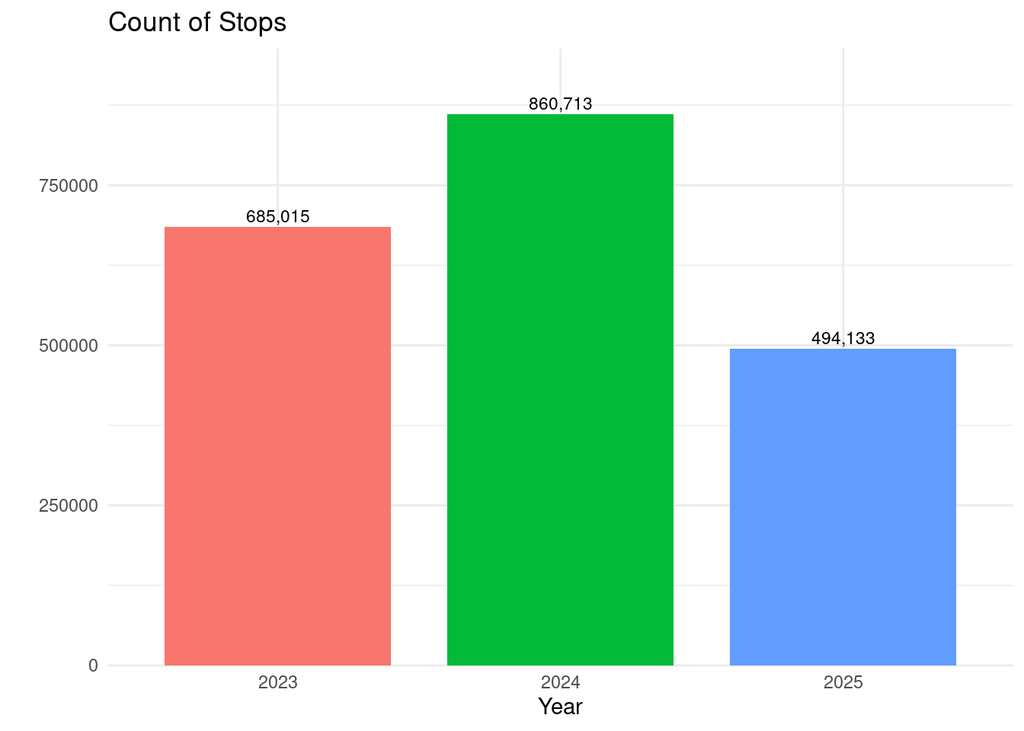

```r
vehstops %>%
  filter(!is.na(year)) %>%
  count(year, name = "n") %>%
  ggplot(aes(x = factor(year), y = n, fill = factor(year))) +
  geom_col(width = 0.8, show.legend = FALSE) +
  geom_text(aes(label = scales::comma(n)), vjust = -0.35, size = 3) +
  scale_y_continuous(expand = expansion(mult = c(0, 0.12))) +
  coord_cartesian(clip = "off") +
  labs(x = "Year", y = "", title = "Count of Stops") +
  theme_minimal()
```

### Month

Since it is not safe to group by year 2025 only has around 6 months of data), we divide this in 3 parts.

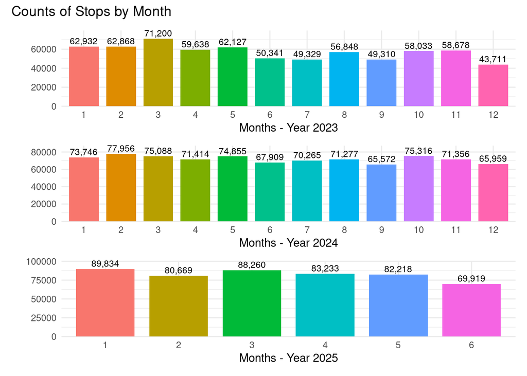

```r
p1 <- vehstops %>%
  filter(!is.na(year) & year == 2023) %>%
  count(month, name = "n") %>%
  ggplot(aes(x = factor(month), y = n, fill = factor(month))) +
  geom_col(width = 0.8, show.legend = FALSE) +
  geom_text(aes(label = scales::comma(n)), vjust = -0.35, size = 3) +
  scale_y_continuous(expand = expansion(mult = c(0, 0.12))) +
  coord_cartesian(clip = "off") +
  labs(x = "Months - Year 2023", y = "") +
  theme_minimal()

p2 <- vehstops %>%
  filter(!is.na(year) & year == 2024) %>%
  count(month, name = "n") %>%
  ggplot(aes(x = factor(month), y = n, fill = factor(month))) +
  geom_col(width = 0.8, show.legend = FALSE) +
  geom_text(aes(label = scales::comma(n)), vjust = -0.35, size = 3) +
  scale_y_continuous(expand = expansion(mult = c(0, 0.12))) +
  coord_cartesian(clip = "off") +
  labs(x = "Months - Year 2024", y = "") +
  theme_minimal()

p3 <- vehstops %>%
  filter(!is.na(year) & year == 2025) %>%
  count(month, name = "n") %>%
  ggplot(aes(x = factor(month), y = n, fill = factor(month))) +
  geom_col(width = 0.8, show.legend = FALSE) +
  geom_text(aes(label = scales::comma(n)), vjust = -0.35, size = 3) +
  scale_y_continuous(expand = expansion(mult = c(0, 0.12))) +
  coord_cartesian(clip = "off") +
  labs(x = "Months - Year 2025", y = "") +
  theme_minimal()

(p1 / p2 / p3) +
  plot_layout(widths = c(2, 2), guides = "collect") +
  plot_annotation(title = "Counts of Stops by Month") &
  theme(legend.position = "bottom")
```

In fact, now it makes more sense, because the cumulative sum of the first six months of the year of 2025 is higher than the first six months of the previous years!

### Day and Dow

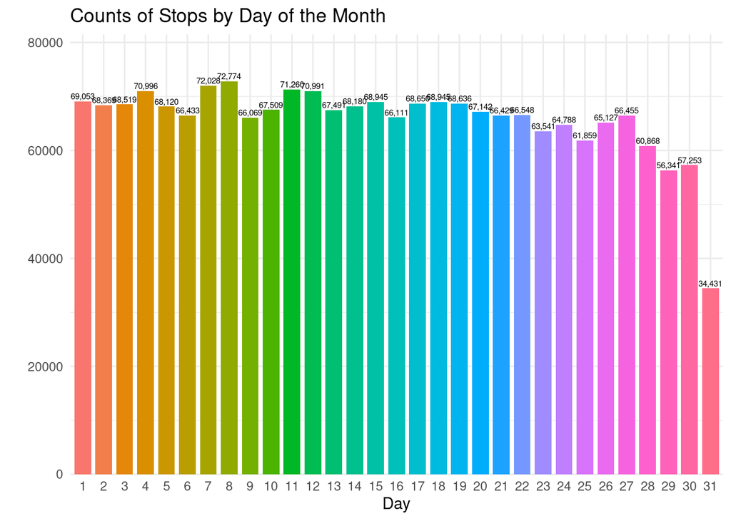

```r
vehstops %>%
  filter(!is.na(day)) %>%
  count(day, name = "n") %>%
  ggplot(aes(x = factor(day), y = n, fill = factor(day))) +
  geom_col(width = 0.8, show.legend = FALSE) +
  geom_text(aes(label = scales::comma(n)), vjust = -0.35, size = 2) +
  scale_y_continuous(expand = expansion(mult = c(0, 0.12))) +
  coord_cartesian(clip = "off") +
  labs(x = "Day", y = "", title="Counts of Stops by Day of the Month") +
  theme_minimal()
```

The day of the month does not seem to matter much and we see a decrease on the `31` day because not all months have them.

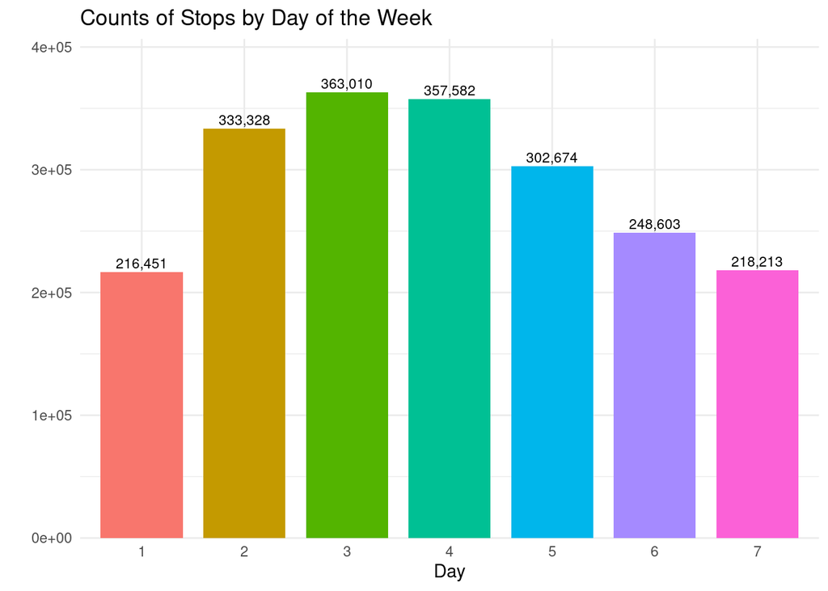

```r
vehstops %>%
  filter(!is.na(dow)) %>%
  count(dow, name = "n") %>%
  ggplot(aes(x = factor(dow), y = n, fill = factor(dow))) +
  geom_col(width = 0.8, show.legend = FALSE) +
  geom_text(aes(label = scales::comma(n)), vjust = -0.35, size = 3) +
  scale_y_continuous(expand = expansion(mult = c(0, 0.12))) +
  coord_cartesian(clip = "off") +
  labs(x = "Day", y = "", title="Counts of Stops by Day of the Week") +
  theme_minimal()
```

This `doy` is hard to account for, and we are going to remove it from the clean version

```r
vehstops2 <- vehstops2 %>%
  select(-doy)
```

### Hour, Working Hour and Time Bracket

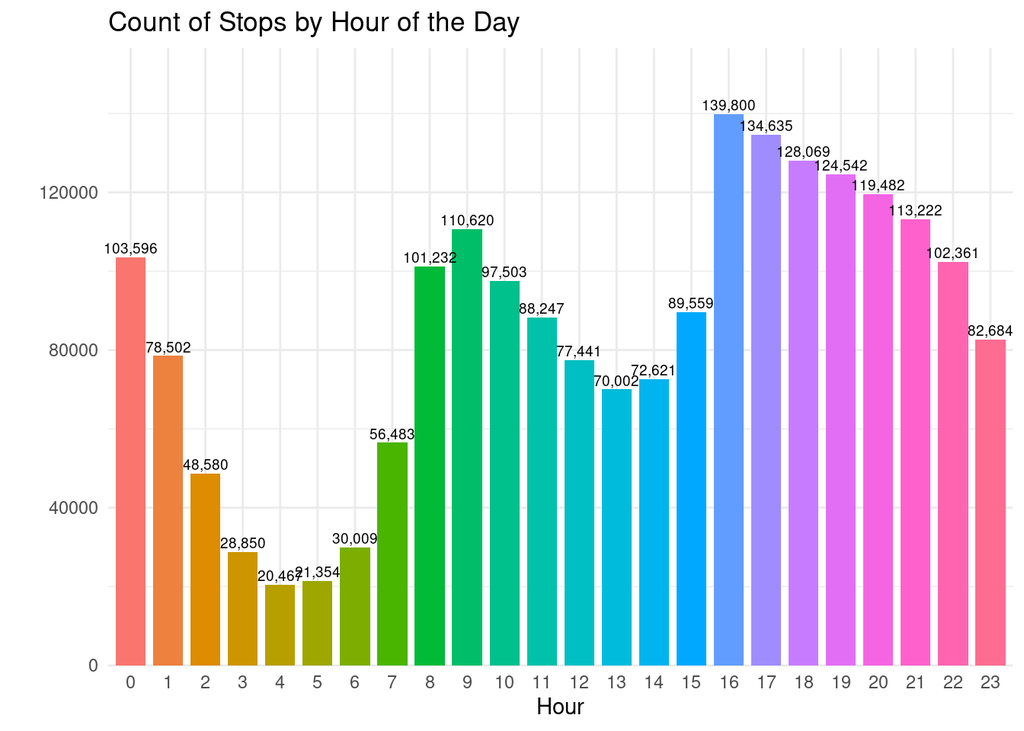

```r
vehstops %>%
  filter(!is.na(hour)) %>%
  count(hour, name = "n") %>%
  ggplot(aes(x = factor(hour), y = n, fill = factor(hour))) +
  geom_col(width = 0.8, show.legend = FALSE) +
  geom_text(aes(label = scales::comma(n)), vjust = -0.35, size = 2.5) +
  scale_y_continuous(expand = expansion(mult = c(0, 0.12))) +
  coord_cartesian(clip = "off") +
  labs(x = "Hour", y = "", title = "Count of Stops by Hour of the Day") +
  theme_minimal()
```

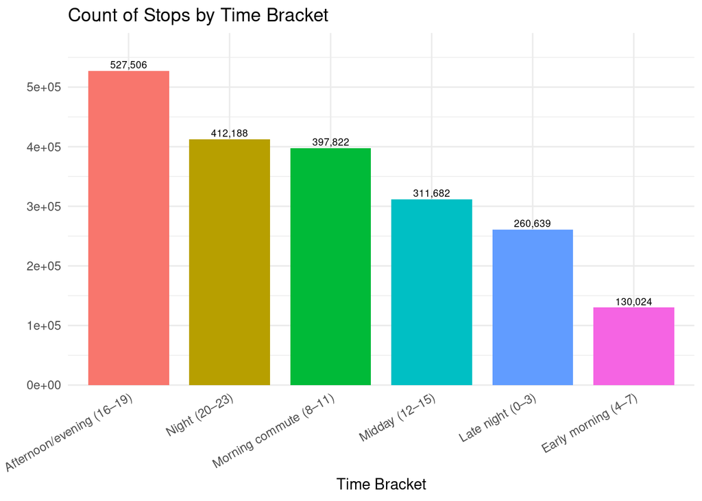

```r
vehstops %>%
  filter(!is.na(time_bracket)) %>%
  count(time_bracket, name = "n") %>%
  mutate(time_bracket = fct_reorder(as.factor(time_bracket), n, .desc = TRUE)) %>%
  ggplot(aes(x = factor(time_bracket), y = n, fill = factor(time_bracket))) +
  geom_col(width = 0.8, show.legend = FALSE) +
  geom_text(aes(label = scales::comma(n)), vjust = -0.35, size = 2.5) +
  scale_y_continuous(expand = expansion(mult = c(0, 0.12))) +
  coord_cartesian(clip = "off") +
  labs(x = "Time Bracket", y = "", title = "Count of Stops by Time Bracket") +
  theme_minimal() +
  scale_x_discrete(guide = guide_axis(angle = 30, n.dodge = 1))
```

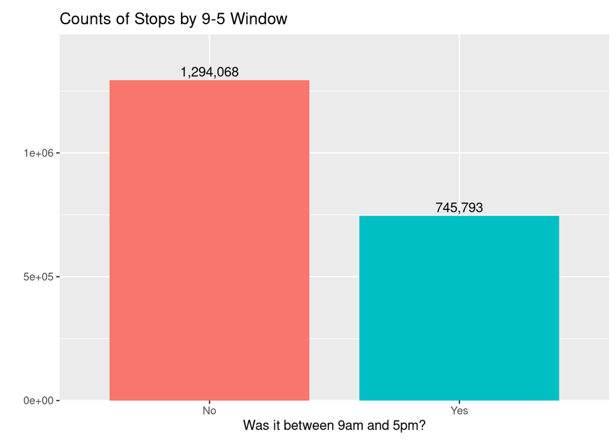

```r
plot_binary_bar(
  vehstops, working_hour,
  "No", "Yes",
  "Was it between 9am and 5pm?", "", "Counts of Stops by 9-5 Window"
)
```

### Minute

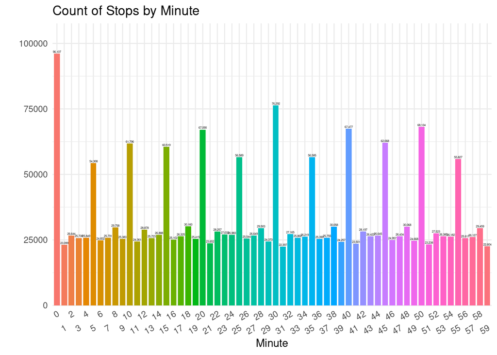

```r
vehstops %>%
  filter(!is.na(minute)) %>%
  count(minute, name = "n") %>%
  ggplot(aes(x = factor(minute), y = n, fill = factor(minute))) +
  geom_col(width = 0.8, show.legend = FALSE) +
  geom_text(aes(label = scales::comma(n)), vjust = -0.35, size = 1) +
  scale_y_continuous(expand = expansion(mult = c(0, 0.12))) +
  coord_cartesian(clip = "off") +
  labs(x = "Minute", y = "", title = "Count of Stops by Minute") +
  theme_minimal() +
  scale_x_discrete(guide = guide_axis(angle = 30, n.dodge = 2))
```

This seems to either require some binning or just drop, but we are going to drop it for the clean version.

```r
vehstops2 <- vehstops2 %>%
  select(-minute)
```

### Weekend, Holiday and Event Day

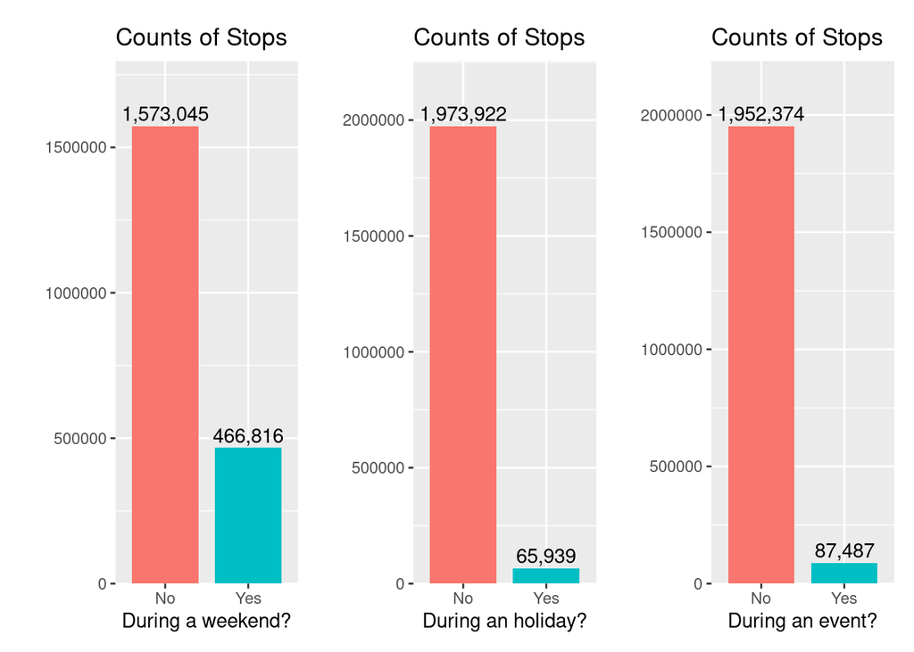

```r
p1 <- plot_binary_bar(
  vehstops, weekend,
  "No", "Yes",
  "During a weekend?", "", "Counts of Stops"
)

p2 <- plot_binary_bar(
  vehstops, holiday,
  "No", "Yes",
  "During an holiday?", "", "Counts of Stops"
)

p3 <- plot_binary_bar(
  vehstops, event_day,
  "No", "Yes",
  "During an event?", "", "Counts of Stops"
)

(p1 + p2 + p3) +
  plot_layout(ncol = 3, nrow = 1, widths = c(1, 1), guides = "collect") +
  theme(legend.position = "bottom")
```

None of the two matter much in terms of stops

## Motorist related features

### Reported Age

We have mainly 2 issues here. First, we have many instances of drivers with unknown age

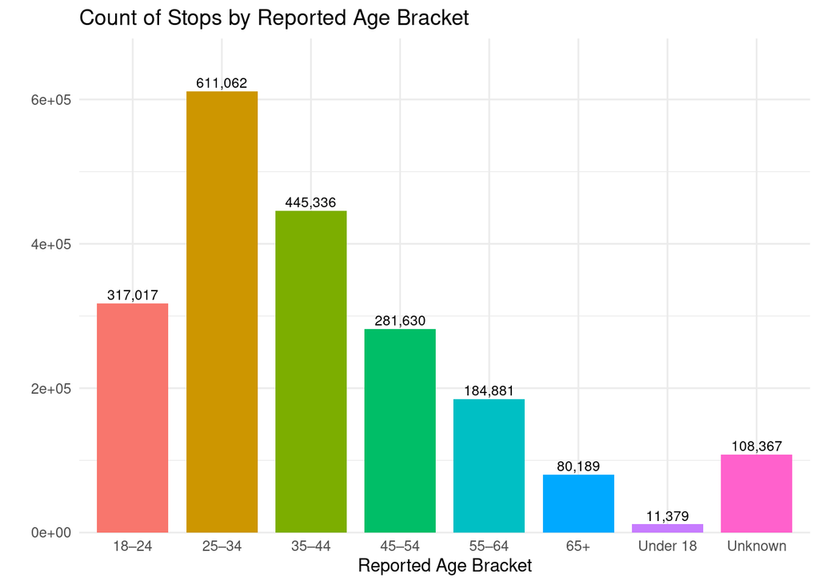

```r
vehstops %>%
  filter(!is.na(age_bracket)) %>%
  count(age_bracket, name = "n") %>%
  ggplot(aes(x = factor(age_bracket), y = n, fill = factor(age_bracket))) +
  geom_col(width = 0.8, show.legend = FALSE) +
  geom_text(aes(label = scales::comma(n)), vjust = -0.35, size = 3) +
  scale_y_continuous(expand = expansion(mult = c(0, 0.12))) +  # top padding
  coord_cartesian(clip = "off") +
  labs(x = "Reported Age Bracket", y = "", title = "Count of Stops by Reported Age Bracket") +
  theme_minimal()
```

But if we forget about them and we plot the distribution

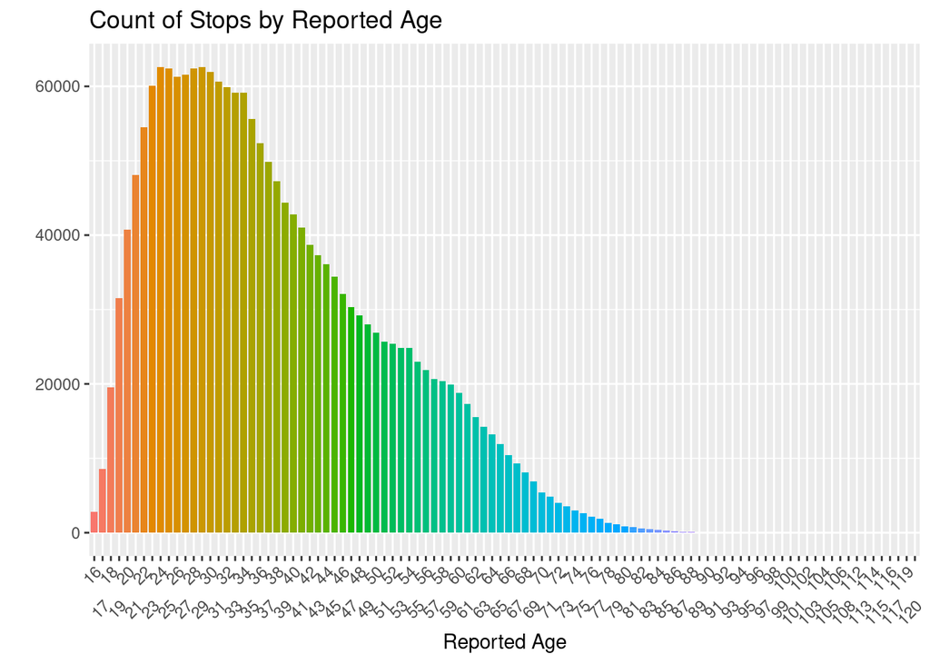

```r
vehstops %>%
  filter(!is.na(age)) %>%
  count(age) %>%
  ggplot(aes(y = n,x = factor(age), fill = factor(age))) +
  geom_col(width = 0.8, na.rm = TRUE, show.legend = FALSE) +
  labs(x = "Reported Age", y = "", title = "Count of Stops by Reported Age") +
  scale_x_discrete(guide = guide_axis(angle = 45, n.dodge = 2))
```

We can see that our second issue is the presence of very old drivers (90+),

```r
vehstops %>%
  select(year, month, hour, time_bracket, area, age, sex, race, veh_categ, any_escalation) %>%
  filter(age > 90) %>%
  dfSummary()
```

```
## Data Frame Summary
## vehstops
## Dimensions: 139 x 10
## Duplicates: 0
##
## --------------------------------------------------------------------------------------------------------------------
## No   Variable         Stats / Values                 Freqs (% of Valid)   Graph                 Valid      Missing
## ---- ---------------- ------------------------------ -------------------- --------------------- ---------- ---------
## 1    year             Mean (sd) : 2023.8 (0.7)       2023 : 45 (32.4%)    IIIIII                139        0
##      [integer]        min < med < max:               2024 : 71 (51.1%)    IIIIIIIIII            (100.0%)   (0.0%)
##                       2023 < 2024 < 2025             2025 : 23 (16.5%)    III
##                       IQR (CV) : 1 (0)
##
## 2    month            Mean (sd) : 5.8 (3.6)          12 distinct values   :                     139        0
##      [integer]        min < med < max:                                    :                 :   (100.0%)   (0.0%)
##                       1 < 5 < 12                                          : : :             :
##                       IQR (CV) : 6 (0.6)                                  : : : :     .   . :
##                                                                           : : : : : . : : : :
##
## 3    hour             Mean (sd) : 12.5 (5.5)         24 distinct values               :         139        0
##      [integer]        min < med < max:                                          . :   :         (100.0%)   (0.0%)
##                       0 < 13 < 23                                               : : : : .
##                       IQR (CV) : 7.5 (0.4)                                .     : : : : : : .
##                                                                           : : . : : : : : : :
##
## 4    time_bracket     1. Afternoon/evening (16–19)   31 (22.3%)           IIII                  139        0
##      [character]      2. Early morning (4–7)         10 ( 7.2%)           I                     (100.0%)   (0.0%)
##                       3. Late night (0–3)            12 ( 8.6%)           I
##                       4. Midday (12–15)              33 (23.7%)           IIII
##                       5. Morning commute (8–11)      37 (26.6%)           IIIII
##                       6. Night (20–23)               16 (11.5%)           II
##
## 5    area             1. Bronx                       16 (11.5%)           II                    139        0
##      [character]      2. Brooklyn                    37 (26.6%)           IIIII                 (100.0%)   (0.0%)
##                       3. Manhattan                   34 (24.5%)           IIII
##                       4. Queens                      33 (23.7%)           IIII
##                       5. Staten Island               19 (13.7%)           II
##
## 6    age              Mean (sd) : 97.7 (7.5)         25 distinct values   :                     139        0
##      [integer]        min < med < max:                                    :                     (100.0%)   (0.0%)
```

[output cut: 10 more lines]

```
##                       3. BLACK                       29 (20.9%)           IIII
##                       4. HISPANIC                    17 (12.2%)           II
##                       5. UNKNOWN                     26 (18.7%)           III
##                       6. WHITE                       55 (39.6%)           IIIIIII
##
## 9    veh_categ        1. BIKE                          2 ( 1.4%)                                139        0
##      [character]      2. CAR/SUV                     126 (90.6%)          IIIIIIIIIIIIIIIIII    (100.0%)   (0.0%)
##                       3. MCL                           2 ( 1.4%)
##                       4. OTHER                         6 ( 4.3%)
##                       5. TRUCK/BUS                     3 ( 2.2%)
##
## 10   any_escalation   Min  : 0                       0 : 138 (99.3%)      IIIIIIIIIIIIIIIIIII   139        0
##      [integer]        Mean : 0                       1 :   1 ( 0.7%)                            (100.0%)   (0.0%)
##                       Max  : 1
## --------------------------------------------------------------------------------------------------------------------
```

Which may not contribute to much here. So in the second version of the dataset we are going to remove drivers older than 90 (but for the full dataset, we are going to wait).

```r
vehstops2 <- vehstops2 %>%
  filter(age <= 90)
```

Thus,

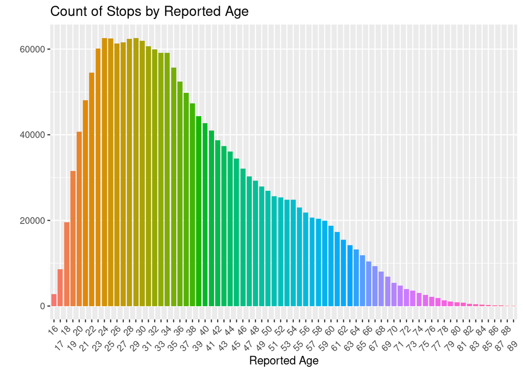

```r
vehstops %>%
  filter(!is.na(age) & age < 90) %>%
  count(age) %>%
  ggplot(aes(y = n,x = factor(age), fill = factor(age))) +
  geom_col(width = 0.8, na.rm = TRUE, show.legend = FALSE) +
  labs(x = "Reported Age", y = "", title = "Count of Stops by Reported Age") +
  scale_x_discrete(guide = guide_axis(angle = 45, n.dodge = 2))
```

If there is evidence of a better binning with respect to the escalation, we might as well re-bin this feature

### Reported Sex

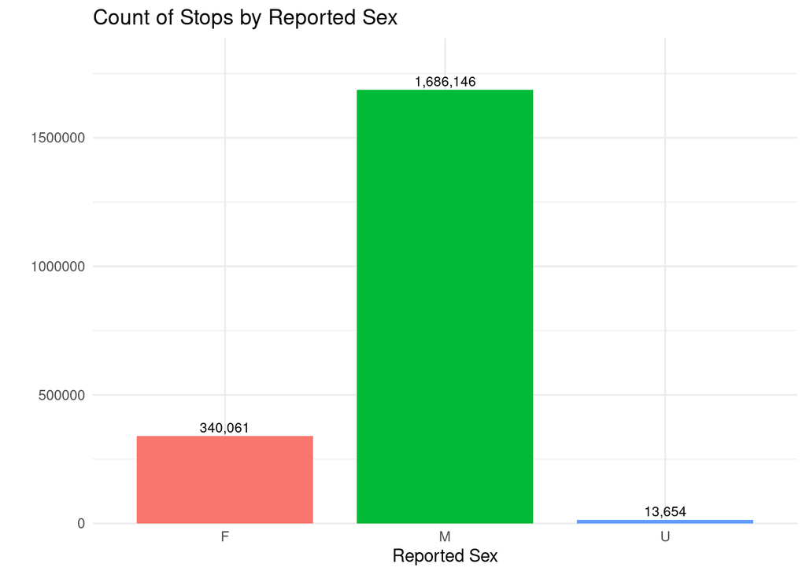

```r
vehstops %>%
  filter(!is.na(sex)) %>%
  count(sex, name = "n") %>%
  ggplot(aes(x = factor(sex), y = n, fill = factor(sex))) +
  geom_col(width = 0.8, show.legend = FALSE) +
  geom_text(aes(label = scales::comma(n)), vjust = -0.35, size = 3) +
  scale_y_continuous(expand = expansion(mult = c(0, 0.12))) +
  coord_cartesian(clip = "off") +
  labs(x = "Reported Sex", y = "", title = "Count of Stops by Reported Sex") +
  theme_minimal()
```

### Reported Race

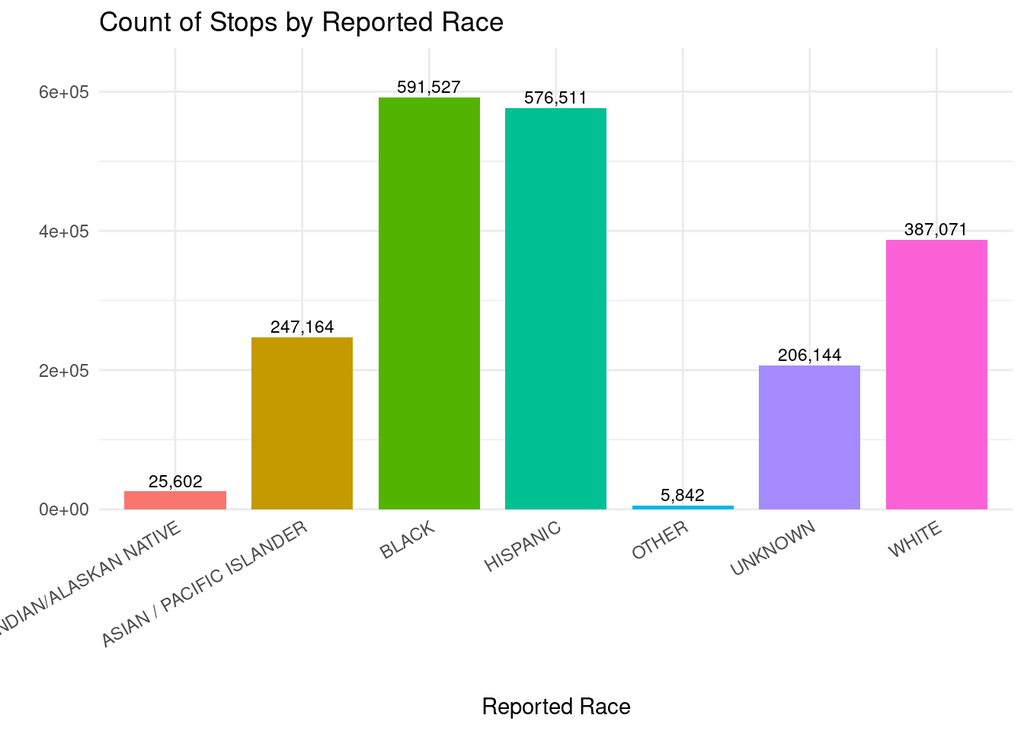

```r
vehstops %>%
  filter(!is.na(race)) %>%
  count(race, name = "n") %>%
  ggplot(aes(x = factor(race), y = n, fill = factor(race))) +
  geom_col(width = 0.8, show.legend = FALSE) +
  geom_text(aes(label = scales::comma(n)), vjust = -0.35, size = 3) +
  scale_y_continuous(expand = expansion(mult = c(0, 0.12))) +
  coord_cartesian(clip = "off") +
  labs(x = "Reported Race", y = "", title = "Count of Stops by Reported Race") +
  theme_minimal() +
  scale_x_discrete(guide = guide_axis(angle = 30, n.dodge = 1))
```

## Vehicle related features

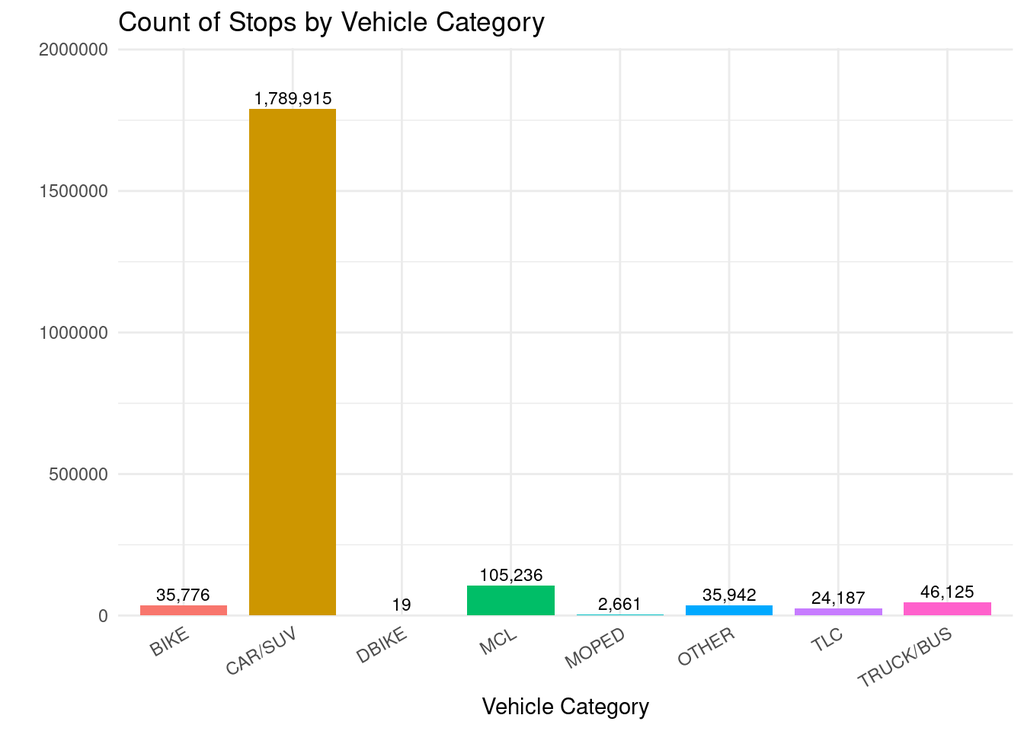

```r
vehstops %>%
  filter(!is.na(veh_categ)) %>%
  count(veh_categ, name = "n") %>%
  ggplot(aes(x = factor(veh_categ), y = n, fill = factor(veh_categ))) +
  geom_col(width = 0.8, show.legend = FALSE) +
  geom_text(aes(label = scales::comma(n)), vjust = -0.35, size = 3) +
  scale_y_continuous(expand = expansion(mult = c(0, 0.12))) +
  coord_cartesian(clip = "off") +
  labs(x = "Vehicle Category", y = "", title = "Count of Stops by Vehicle Category") +
  theme_minimal() +
  scale_x_discrete(guide = guide_axis(angle = 30, n.dodge = 1))
```

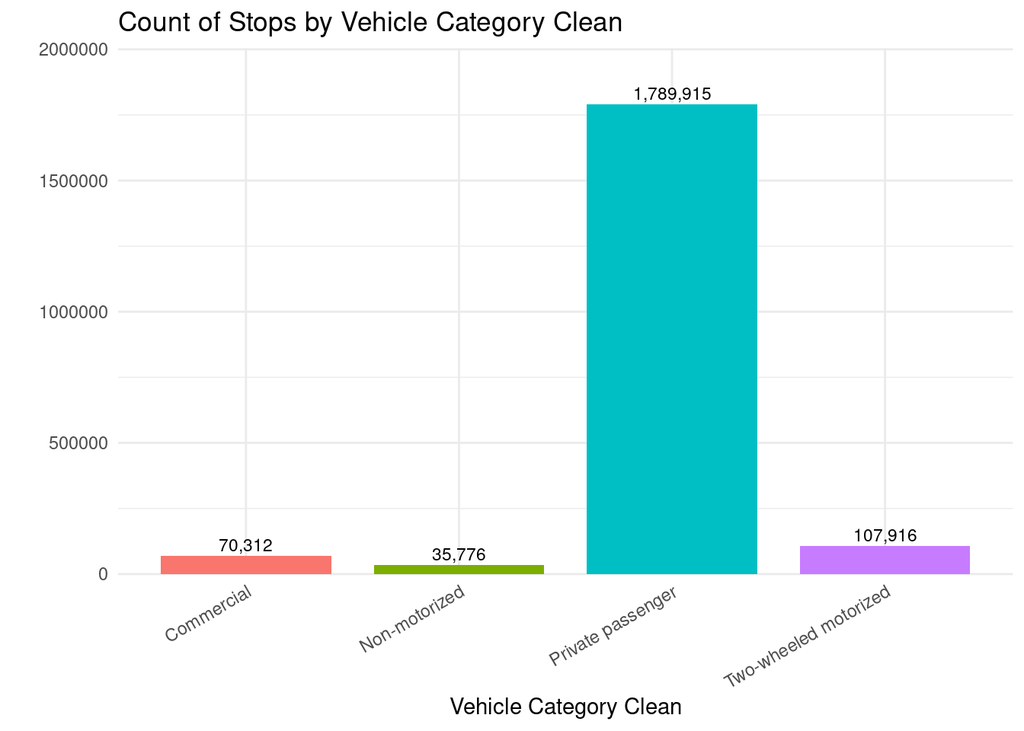

```r
vehstops %>%
  filter(!is.na(veh_categ_clean)) %>%
  count(veh_categ_clean, name = "n") %>%
  ggplot(aes(x = factor(veh_categ_clean), y = n, fill = factor(veh_categ_clean))) +
  geom_col(width = 0.8, show.legend = FALSE) +
  geom_text(aes(label = scales::comma(n)), vjust = -0.35, size = 3) +
  scale_y_continuous(expand = expansion(mult = c(0, 0.12))) +
  coord_cartesian(clip = "off") +
  labs(x = "Vehicle Category Clean", y = "", title = "Count of Stops by Vehicle Category Clean") +
  theme_minimal() +
  scale_x_discrete(guide = guide_axis(angle = 30, n.dodge = 1))
```

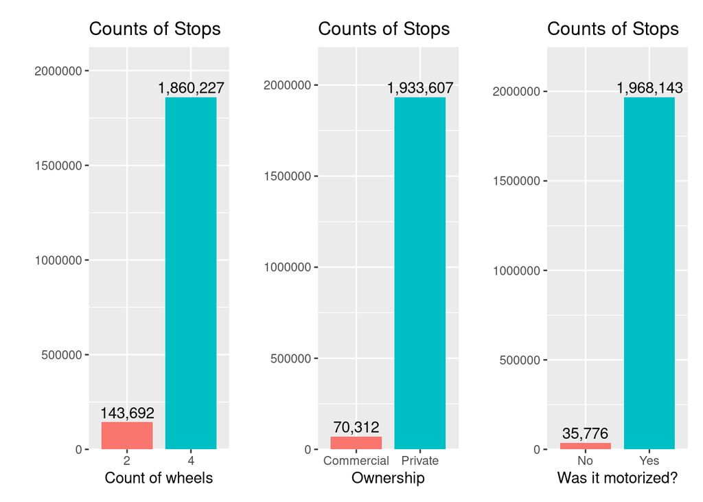

```r
p1 <- plot_binary_bar(
  vehstops, veh_4_wheels,
  "2", "4",
  "Count of wheels", "", "Counts of Stops"
)

p2 <- plot_binary_bar(
  vehstops, veh_private,
  "Commercial", "Private",
  "Ownership", "", "Counts of Stops"
)

p3 <- plot_binary_bar(
  vehstops, veh_motorized,
  "No", "Yes",
  "Was it motorized?", "", "Counts of Stops"
)

(p1 + p2 + p3) +
  plot_layout(ncol = 3, nrow = 1, widths = c(1, 1), guides = "collect") +
  theme(legend.position = "bottom")
```

# Bivariate EDA

Here forget about just analyzing the stops counts and we switch towards the main feature to see the proportion.

## Collinearity

## Command Unit, Geospatial and Area related Features

### Area

```r
ratio_by_cat(
  vehstops, any_escalation, area,
  "Area", "Share of stops", "Escalation ratio by area",
  style = "stack"
)
```

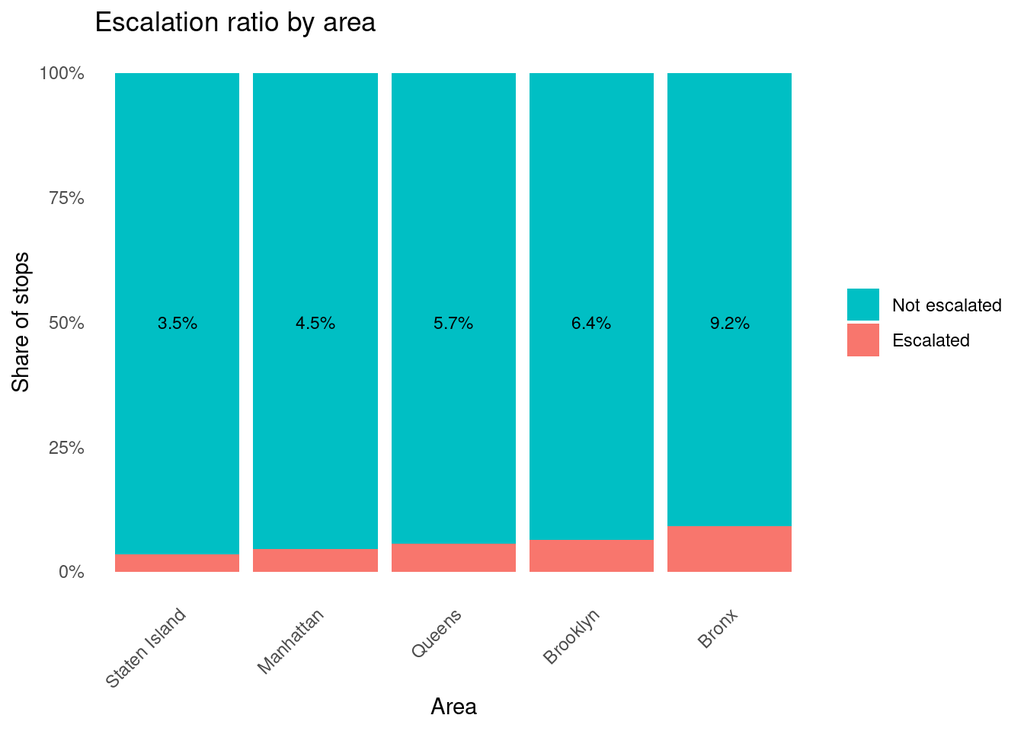

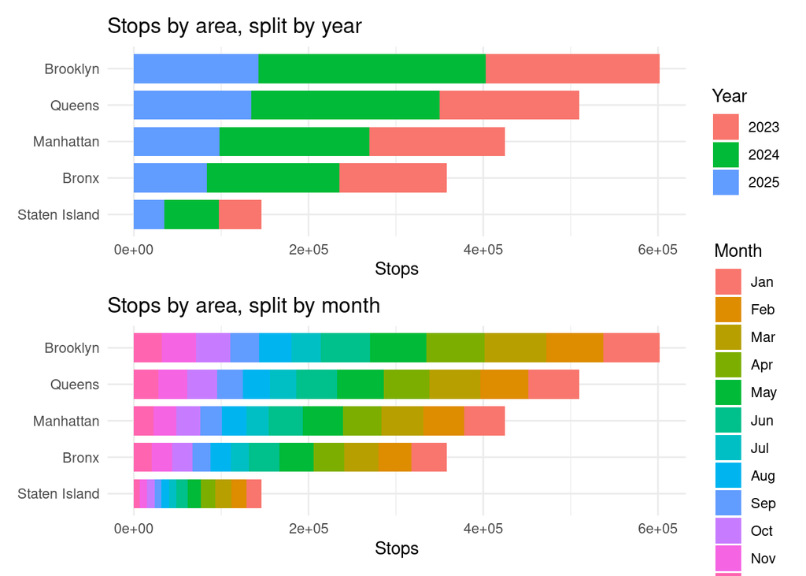

```r
p1 <- vehstops %>%
  filter(!is.na(area), !is.na(year)) %>%
  count(area, year, name = "n") %>%
  group_by(area) %>% mutate(total = sum(n)) %>% ungroup() %>%
  mutate(area = fct_reorder(area, total),
         year = factor(year)) %>%
  ggplot(aes(x = n, y = area, fill = year)) +
  geom_col(width = 0.8) +
  labs(x = "Stops", y = NULL, fill = "Year",
       title = "Stops by area, split by year") +
  theme_minimal()

p2 <- vehstops %>%
  filter(!is.na(area), !is.na(month)) %>%
  count(area, month, name = "n") %>%
  group_by(area) %>% mutate(total = sum(n)) %>% ungroup() %>%
  mutate(area  = fct_reorder(area, total),
         month = factor(month, levels = 1:12, labels = month.abb)) %>%
  ggplot(aes(x = n, y = area, fill = month)) +
  geom_col(width = 0.8) +
  labs(x = "Stops", y = NULL, fill = "Month",
       title = "Stops by area, split by month") +
  theme_minimal()

p1 / p2
```

### Borough

```r
ratio_by_cat(
  vehstops, any_escalation, boro,
  "Borough", "Share of stops", "Escalation ratio by borough",
  style = "stack"
)
```

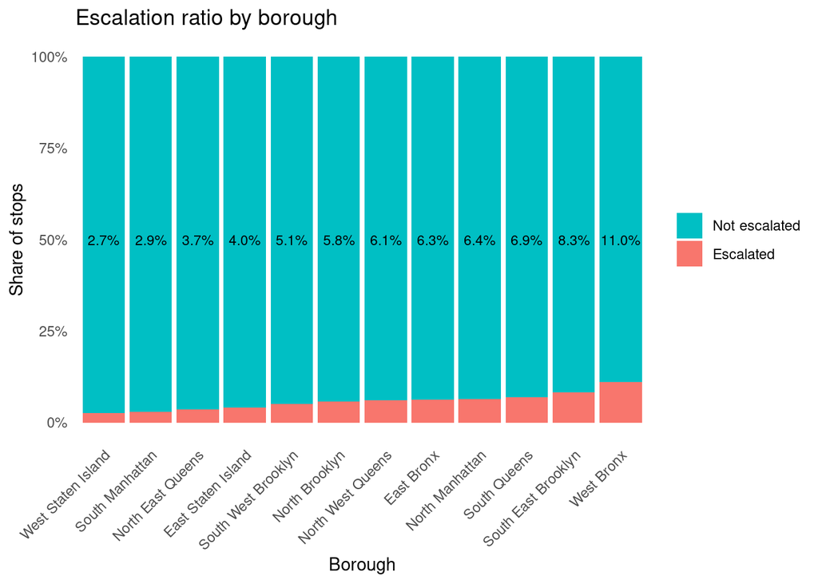

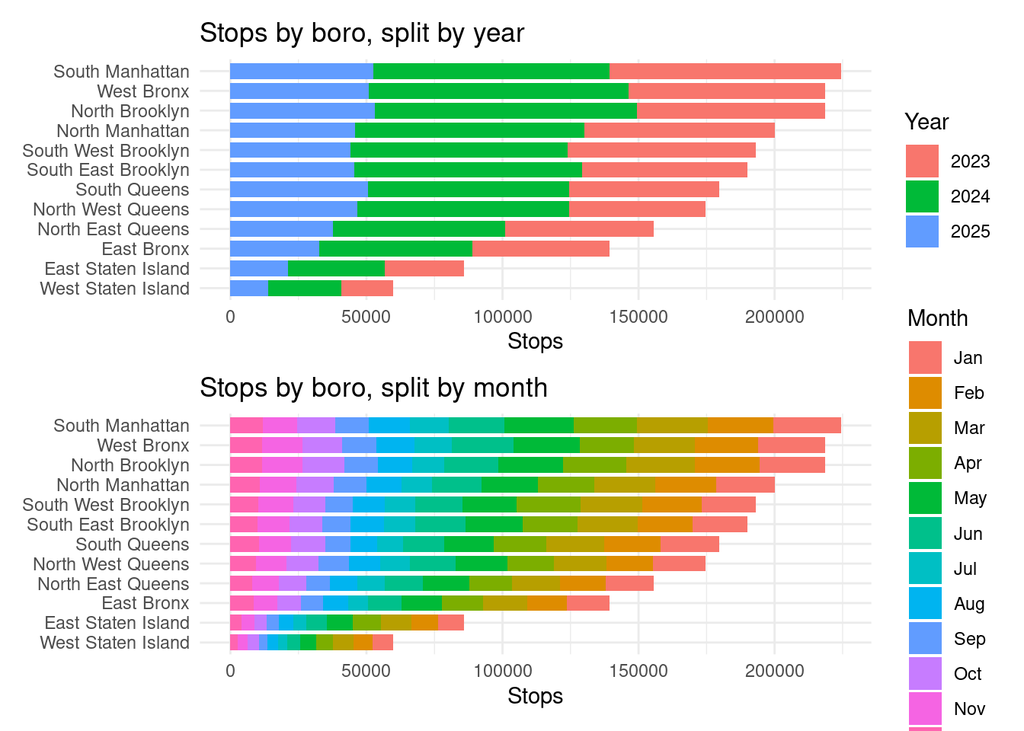

```r
p1 <- vehstops %>%
  filter(!is.na(boro), !is.na(year)) %>%
  count(boro, year, name = "n") %>%
  group_by(boro) %>% mutate(total = sum(n)) %>% ungroup() %>%
  mutate(boro = fct_reorder(boro, total),
         year = factor(year)) %>%
  ggplot(aes(x = n, y = boro, fill = year)) +
  geom_col(width = 0.8) +
  labs(x = "Stops", y = NULL, fill = "Year",
       title = "Stops by boro, split by year") +
  theme_minimal()

p2 <- vehstops %>%
  filter(!is.na(boro), !is.na(month)) %>%
  count(boro, month, name = "n") %>%
  group_by(boro) %>% mutate(total = sum(n)) %>% ungroup() %>%
  mutate(boro  = fct_reorder(boro, total),
         month = factor(month, levels = 1:12, labels = month.abb)) %>%
  ggplot(aes(x = n, y = boro, fill = month)) +
  geom_col(width = 0.8) +
  labs(x = "Stops", y = NULL, fill = "Month",
       title = "Stops by boro, split by month") +
  theme_minimal()

p1 / p2
```

### Command

```r
# FIXME
ratio_by_cat(
  vehstops, any_escalation, command,
  "Command", "Share of stops", "Escalation ratio by command",
  style = "stack"
)
```

[figure not shown]

[figure not shown]

```r
# FIXME
p1 <- vehstops %>%
  filter(!is.na(command), !is.na(year)) %>%
  count(command, year, name = "n") %>%
  group_by(command) %>% mutate(total = sum(n)) %>% ungroup() %>%
  mutate(command = fct_reorder(as.factor(command), total), year = factor(year)) %>%
  ggplot(aes(x = n, y = command, fill = year)) +
  geom_col(width = 0.8) +
  labs(x = "Stops", y = NULL, fill = "Year",
       title = "Stops by Command, split by year") +
  theme_minimal()

p2 <- vehstops %>%
  filter(!is.na(command), !is.na(month)) %>%
  count(command, month, name = "n") %>%
  group_by(command) %>% mutate(total = sum(n)) %>% ungroup() %>%
  mutate(command  = fct_reorder(as.factor(command), total),
         month = factor(month, levels = 1:12, labels = month.abb)) %>%
  ggplot(aes(x = n, y = command, fill = month)) +
  geom_col(width = 0.8) +
  labs(x = "Stops", y = NULL, fill = "Month",
       title = "Stops by Command, split by month") +
  theme_minimal()

p1 / p2
```

## Time related features

### Year

```r
ratio_by_cat(
  vehstops, any_escalation, year,
  "Year", "Share of stops", "Escalation ratio by year",
  style = "stack"
)
```

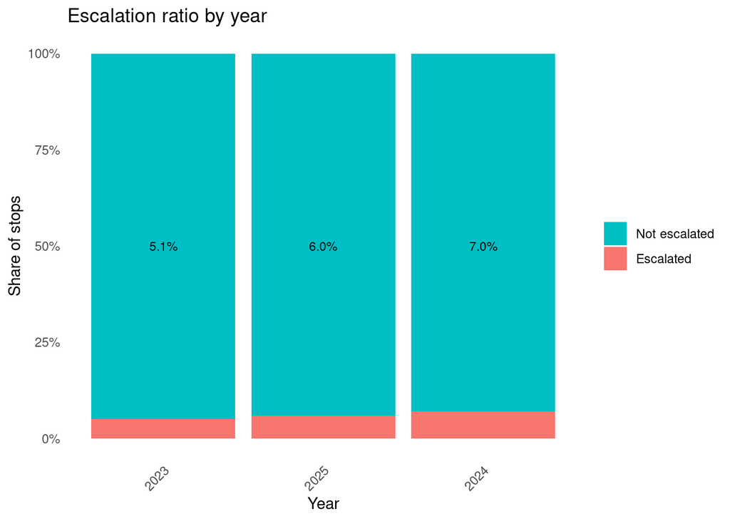